# Infinite Sites Mutation

Eric C. Anderson

```r
library(tidyverse)
library(GSImulator)
library(ape)
library(ggtree)
```

`ms` will simulate infinite sites mutation very readily. There are two options.

First we can tell it to simulate an exact number of segregating sites (like 7, for example):

```r
cat("101 203", file = "seedms")  # this sets the seed for ms
system2(command = ms_binary(), args = "10 1 -s 7 -T")
```

```
/Users/eriq/Library/R/4.3/library/GSImulator/bin/ms-Darwin 10 1 -s 7 -T
101 203 59243

//
(1:0.342,((3:0.079,(7:0.011,(4:0.009,10:0.009):0.002):0.068):0.205,(9:0.121,((2:0.015,8:0.015):0.023,(5:0.017,6:0.017):0.020):0.084):0.163):0.057);
segsites: 7
positions: 0.0769 0.1640 0.3143 0.3899 0.4311 0.7488 0.9669
0000000
0001001
0101100
0101000
0001011
0001001
0101000
0001001
1011001
0101000
```

Notice that the samples can be thought of as being labeled 1–10, and the mutations can be thought of as being labeled 1–7. Each line like 0010010 is an individual gene sequence sample. A 1 means it inherited the mutation, and a 0 means it inherited the non-mutated base.

## In class exercise 1 with 7 groups

Work with your group. Each group will be assigned a site (i.e. a mutation). Figure out which upon which branch in the tree, below, that mutation must have occurred. Each group will then stick their mutation to their branch with some tape.

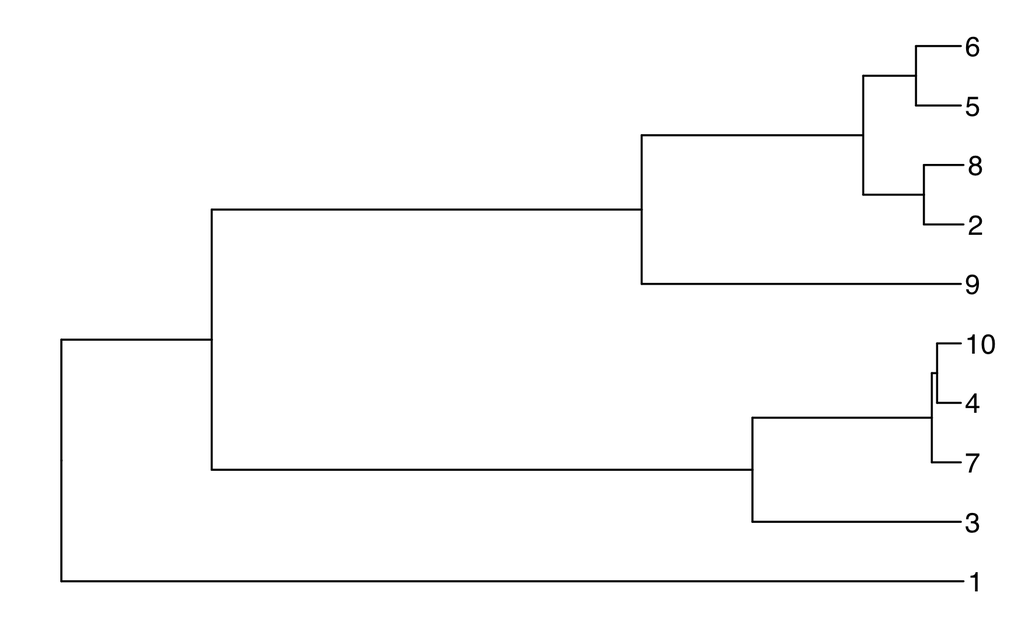

## In class excerise 2

This exercise will get us thinking about what is called the “four-gamete test”. Each group will take their site and one other site that they can choose from amongst the 7, and count up the number of different pairs of mutations at the two sites are found by looking at the segretating sites output above, and then write that on the board.  
For example, for sites 1 and 2 the result that gets written on the board should look like:

| Pair | n |
| --- | --- |
| 00 | 5 |
| 01 | 4 |
| 10 | 1 |

Each group will do this with two pairs of sites. For example, if your group is assigned site 1, you might to it for sites 1 and 2 and sites 1 and 5.

Write each little table on the board with a title like “Sites 1,2” above each. When that is done, we will talk about it.